# Laboratory Eight - Cluster Analysis II

## Data set - compound

```python
import pandas as pd

firstdata = pd.read_csv('/Users/adunifekizitookoye/Desktop/CSCI 4150U - Data Mining/datasets2/compound.txt', header=None)
firstdata.columns = ['first']
firstdata.head()
```

|  | first |
| --- | --- |
| 0 | 26.75\t22.15\t1 |
| 1 | 29.8\t22.15\t1 |
| 2 | 31.55\t21.1\t1 |
| 3 | 27.7\t20.85\t1 |
| 4 | 29.9\t19.95\t1 |

```python
#tablulated
firstdata = pd.read_csv('/Users/adunifekizitookoye/Desktop/CSCI 4150U - Data Mining/datasets2/compound.txt', delimiter='\t', header=None)
firstdata.columns = ['col1', 'col2', 'Class']
data1 = firstdata
data1.head()
```

|  | col1 | col2 | Class |
| --- | --- | --- | --- |
| 0 | 26.75 | 22.15 | 1 |
| 1 | 29.80 | 22.15 | 1 |
| 2 | 31.55 | 21.10 | 1 |
| 3 | 27.70 | 20.85 | 1 |
| 4 | 29.90 | 19.95 | 1 |

### Part I:

1. Perform k-means clustering on different data sets using different k (e.g., 2-6)

```python
from sklearn import cluster
compound = data1.drop(['Class'],axis=1)
k_means = cluster.KMeans(n_clusters=2, max_iter=50, random_state=1)
k_means.fit(compound)
labels = pd.DataFrame(k_means.labels_,columns =['Cluster ID'])
result = pd.concat((compound, labels), axis=1)
```

1. Visualize the clustering results using scatter plots for different k

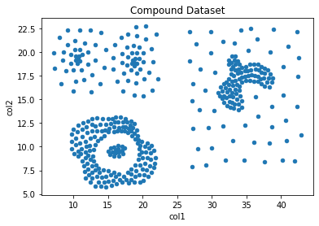

```python
import pandas as pd
import matplotlib.pyplot as plt
%matplotlib inline

result.plot.scatter(x='col1', y='col2')
plt.title('Compound Dataset')
```

1. Calculate the SSE and plot sum-of-squared errors (SSE) versus k

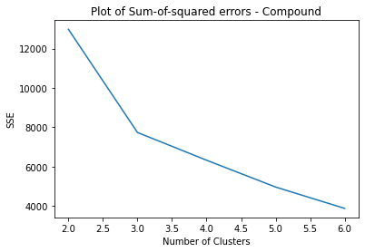

```python
import matplotlib.pyplot as plt
%matplotlib inline

numClusters = [2,3,4,5,6]
SSE = []
for k in numClusters:
    k_means = cluster.KMeans(n_clusters=k)
    k_means.fit(compound)
    SSE.append(k_means.inertia_)

plt.plot(numClusters, SSE)
plt.title('Plot of Sum-of-squared errors - Compound')
plt.xlabel('Number of Clusters')
plt.ylabel('SSE')
```

1. Discuss the results of part (2) and (3)

For part (2) I noticed the visually obvious clusters For part (3) I noticed the value of the best K didn't seem obvious.

### Part II:

1. Perform DBSCAN clustering on different data sets using different Eps and MinPt
2. Draw the distance to k nearest point versus k (for different k)
   - Try to find the estimation of Eps and MinPt (see DBSCAN: Determining EPS and MinPts slide)

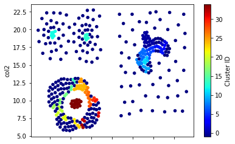

```python
from sklearn.cluster import DBSCAN
import numpy as np

db = DBSCAN(eps=0.5, min_samples=2).fit(data1)
labels = pd.DataFrame(db.labels_,columns=['Cluster ID'])
result = pd.concat((data1,labels), axis=1)
result.plot.scatter(x='col1', y='col2',c='Cluster ID', colormap='jet')
```

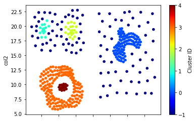

```python
from sklearn.cluster import DBSCAN
import numpy as np

db = DBSCAN(eps=1, min_samples=3).fit(data1)
labels = pd.DataFrame(db.labels_,columns=['Cluster ID'])
result = pd.concat((data1,labels), axis=1)
result.plot.scatter(x='col1', y='col2',c='Cluster ID', colormap='jet')
```

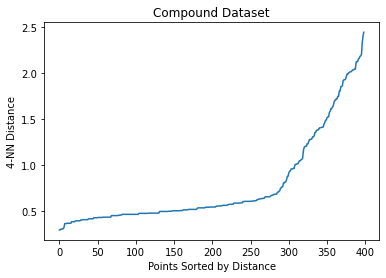

```python
from sklearn.neighbors import NearestNeighbors
import numpy as np
from scipy.spatial import distance

neighbors = NearestNeighbors(n_neighbors = 4)
neighbors_fit = neighbors.fit(compound)
distances, indices = neighbors_fit.kneighbors(compound)

distances = np.sort(distances, axis=0)
distances = distances[:,1]
plt.plot(distances)
plt.ylabel('4-NN Distance')
plt.xlabel('Points Sorted by Distance')
plt.title('Compound Dataset')
```

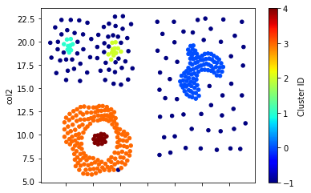

```python
from sklearn.cluster import DBSCAN
import numpy as np

db = DBSCAN(eps=0.75, min_samples=4).fit(data1)
labels = pd.DataFrame(db.labels_,columns=['Cluster ID'])
result = pd.concat((data1,labels), axis=1)
result.plot.scatter(x='col1', y='col2',c='Cluster ID', colormap='jet')
```

### Part III:

1. Compare the results of part I and II and discuss the advantages and limitations

Part I didn't have color distinguished pictorial depiction of the points where as Part II did have multiple vartiations of that distinguished pictorial depiction. Ultimately yeilding better clusters.

In this section, the non-globals was a limitation

## Data set - flame

```python
import pandas as pd

seconddata = pd.read_csv('/Users/adunifekizitookoye/Desktop/CSCI 4150U - Data Mining/datasets2/flame.txt', header=None)
seconddata.columns = ['first']
seconddata.head()
```

|  | first |
| --- | --- |
| 0 | 1.85\t27.8\t1 |
| 1 | 1.35\t26.65\t1 |
| 2 | 1.4\t23.25\t2 |
| 3 | 0.85\t23.05\t2 |
| 4 | 0.5\t22.35\t2 |

```python
#tablulated
seconddata = pd.read_csv('/Users/adunifekizitookoye/Desktop/CSCI 4150U - Data Mining/datasets2/flame.txt', delimiter='\t', header=None)
seconddata.columns = ['col1', 'col2', 'Class']
data2 = seconddata
data2.head()
```

|  | col1 | col2 | Class |
| --- | --- | --- | --- |
| 0 | 1.85 | 27.80 | 1 |
| 1 | 1.35 | 26.65 | 1 |
| 2 | 1.40 | 23.25 | 2 |
| 3 | 0.85 | 23.05 | 2 |
| 4 | 0.50 | 22.35 | 2 |

### Part I:

1. Perform k-means clustering on different data sets using different k (e.g., 2-6)

```python
from sklearn import cluster
flame = data2.drop(['Class'],axis=1)
k_means = cluster.KMeans(n_clusters=2, max_iter=50, random_state=1)
k_means.fit(flame)
labels2 = pd.DataFrame(k_means.labels_,columns =['Cluster ID'])
result2 = pd.concat((flame, labels2), axis=1)
```

1. Visualize the clustering results using scatter plots for different k

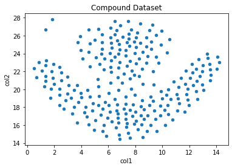

```python
import pandas as pd
import matplotlib.pyplot as plt
%matplotlib inline

result2.plot.scatter(x='col1', y='col2')
plt.title('Compound Dataset')
```

1. Calculate the SSE and plot sum-of-squared errors (SSE) versus k

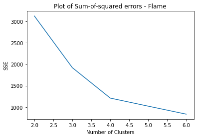

```python
import matplotlib.pyplot as plt
%matplotlib inline

numClusters = [2,3,4,5,6]
SSE = []
for k in numClusters:
    k_means = cluster.KMeans(n_clusters=k)
    k_means.fit(flame)
    SSE.append(k_means.inertia_)

plt.plot(numClusters, SSE)
plt.title('Plot of Sum-of-squared errors - Flame')
plt.xlabel('Number of Clusters')
plt.ylabel('SSE')
```

1. Discuss the results of part (2) and (3)

For part (2) I noticed the visually obvious contiguous clusters For part (3) I noticed the value of the best K was at 4.0

### Part II:

1. Perform DBSCAN clustering on different data sets using different Eps and MinPt
2. Draw the distance to k nearest point versus k (for different k)
   - Try to find the estimation of Eps and MinPt (see DBSCAN: Determining EPS and MinPts slide)

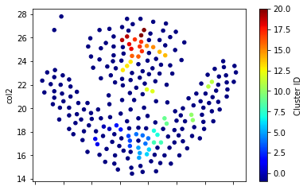

```python
from sklearn.cluster import DBSCAN
import numpy as np

db = DBSCAN(eps=0.5, min_samples=2).fit(data2)
labels = pd.DataFrame(db.labels_,columns=['Cluster ID'])
result = pd.concat((data2,labels), axis=1)
result.plot.scatter(x='col1', y='col2',c='Cluster ID', colormap='jet')
```

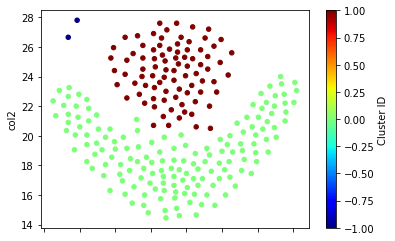

```python
from sklearn.cluster import DBSCAN
import numpy as np

db = DBSCAN(eps=1, min_samples=3).fit(data2)
labels = pd.DataFrame(db.labels_,columns=['Cluster ID'])
result = pd.concat((data2,labels), axis=1)
result.plot.scatter(x='col1', y='col2',c='Cluster ID', colormap='jet')
```

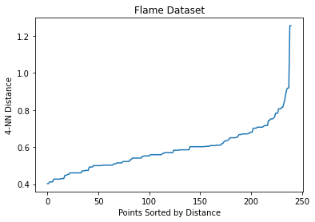

```python
from sklearn.neighbors import NearestNeighbors
import numpy as np
from scipy.spatial import distance

neighbors = NearestNeighbors(n_neighbors = 4)
neighbors_fit = neighbors.fit(flame)
distances, indices = neighbors_fit.kneighbors(flame)

distances = np.sort(distances, axis=0)
distances = distances[:,1]
plt.plot(distances)
plt.ylabel('4-NN Distance')
plt.xlabel('Points Sorted by Distance')
plt.title('Flame Dataset')
```

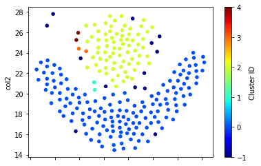

```python
from sklearn.cluster import DBSCAN
import numpy as np

db = DBSCAN(eps=0.8, min_samples=2).fit(data2)
labels = pd.DataFrame(db.labels_,columns=['Cluster ID'])
result = pd.concat((data2,labels), axis=1)
result.plot.scatter(x='col1', y='col2',c='Cluster ID', colormap='jet')
```

### Part III:

1. Compare the results of part I and II and discuss the advantages and limitations

Part I didn't have color distinguished pictorial depiction of the points where as Part II did have multiple vartiations of that distinguished pictorial depiction. Ultimately yeilding better clusters.

In this section, the non-globals was a limitation

## Data set - pathbased

```python
import pandas as pd

thirddata = pd.read_csv('/Users/adunifekizitookoye/Desktop/CSCI 4150U - Data Mining/datasets2/pathbased.txt', header=None)
thirddata.columns = ['first']
thirddata.head()
```

|  | first |
| --- | --- |
| 0 | 11.25\t5.05\t1 |
| 1 | 10.95\t4.7\t1 |
| 2 | 9.85\t5.8\t1 |
| 3 | 9.8\t5.75\t1 |
| 4 | 9.15\t6.8\t1 |

```python
thirddata = pd.read_csv('/Users/adunifekizitookoye/Desktop/CSCI 4150U - Data Mining/datasets2/pathbased.txt', delimiter='\t', header=None)
thirddata.columns = ['col1', 'col2', 'Class']
data3 = thirddata
data3.head()
```

|  | col1 | col2 | Class |
| --- | --- | --- | --- |
| 0 | 11.25 | 5.05 | 1 |
| 1 | 10.95 | 4.70 | 1 |
| 2 | 9.85 | 5.80 | 1 |
| 3 | 9.80 | 5.75 | 1 |
| 4 | 9.15 | 6.80 | 1 |

### Part I:

1. Perform k-means clustering on different data sets using different k (e.g., 2-6)

```python
from sklearn import cluster
pathbased = data3.drop(['Class'],axis=1)
k_means = cluster.KMeans(n_clusters=2, max_iter=50, random_state=1)
k_means.fit(pathbased)
labels3 = pd.DataFrame(k_means.labels_,columns =['Cluster ID'])
result3 = pd.concat((pathbased, labels3), axis=1)
```

1. Visualize the clustering results using scatter plots for different k

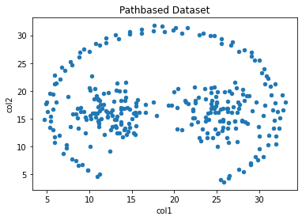

```python
import pandas as pd
import matplotlib.pyplot as plt
%matplotlib inline

result3.plot.scatter(x='col1', y='col2')
plt.title('Pathbased Dataset')
```

1. Calculate the SSE and plot sum-of-squared errors (SSE) versus k

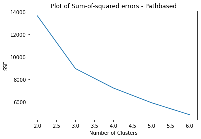

```python
import matplotlib.pyplot as plt
%matplotlib inline

numClusters = [2,3,4,5,6]
SSE = []
for k in numClusters:
    k_means = cluster.KMeans(n_clusters=k)
    k_means.fit(pathbased)
    SSE.append(k_means.inertia_)

plt.plot(numClusters, SSE)
plt.title('Plot of Sum-of-squared errors - Pathbased')
plt.xlabel('Number of Clusters')
plt.ylabel('SSE')
```

1. Discuss the results of part (2) and (3)

For part (2) I noticed the visually obvious contiguous clusters For part (3) I noticed the value of the best K was at not obvious

### Part II:

1. Perform DBSCAN clustering on different data sets using different Eps and MinPt
2. Draw the distance to k nearest point versus k (for different k)
   - Try to find the estimation of Eps and MinPt (see DBSCAN: Determining EPS and MinPts slide)

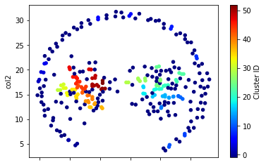

```python
from sklearn.cluster import DBSCAN
import numpy as np

db = DBSCAN(eps=0.5, min_samples=2).fit(data3)
labels = pd.DataFrame(db.labels_,columns=['Cluster ID'])
result = pd.concat((data3,labels), axis=1)
result.plot.scatter(x='col1', y='col2',c='Cluster ID', colormap='jet')
```

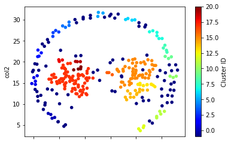

```python
from sklearn.cluster import DBSCAN
import numpy as np

db = DBSCAN(eps=1, min_samples=3).fit(data3)
labels = pd.DataFrame(db.labels_,columns=['Cluster ID'])
result = pd.concat((data3,labels), axis=1)
result.plot.scatter(x='col1', y='col2',c='Cluster ID', colormap='jet')
```

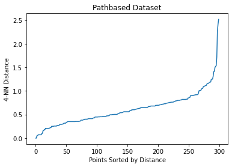

```python
from sklearn.neighbors import NearestNeighbors
import numpy as np
from scipy.spatial import distance

neighbors = NearestNeighbors(n_neighbors = 4)
neighbors_fit = neighbors.fit(pathbased)
distances, indices = neighbors_fit.kneighbors(pathbased)

distances = np.sort(distances, axis=0)
distances = distances[:,1]
plt.plot(distances)
plt.ylabel('4-NN Distance')
plt.xlabel('Points Sorted by Distance')
plt.title('Pathbased Dataset')
```

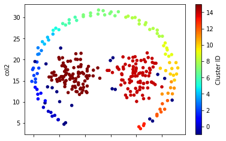

```python
from sklearn.cluster import DBSCAN
import numpy as np

db = DBSCAN(eps=1.5, min_samples=4).fit(data3)
labels = pd.DataFrame(db.labels_,columns=['Cluster ID'])
result = pd.concat((data3,labels), axis=1)
result.plot.scatter(x='col1', y='col2',c='Cluster ID', colormap='jet')
```

### Part III:

1. Compare the results of part I and II and discuss the advantages and limitations

Part I didn't have color distinguished pictorial depiction of the points where as Part II did have multiple vartiations of that distinguished pictorial depiction. Ultimately yeilding better clusters.

In this section, the non-globals was a limitation

## Data set - spiral

```python
import pandas as pd

forthdata = pd.read_csv('/Users/adunifekizitookoye/Desktop/CSCI 4150U - Data Mining/datasets2/spiral.txt', header=None)
forthdata.columns = ['first']
forthdata.head()
```

|  | first |
| --- | --- |
| 0 | 31.95\t7.95\t3 |
| 1 | 31.15\t7.3\t3 |
| 2 | 30.45\t6.65\t3 |
| 3 | 29.7\t6\t3 |
| 4 | 28.9\t5.55\t3 |

```python
forthdata = pd.read_csv('/Users/adunifekizitookoye/Desktop/CSCI 4150U - Data Mining/datasets2/spiral.txt', delimiter='\t', header=None)
forthdata.columns = ['col1', 'col2', 'Class']
data4 = forthdata
data4.head()
```

|  | col1 | col2 | Class |
| --- | --- | --- | --- |
| 0 | 31.95 | 7.95 | 3 |
| 1 | 31.15 | 7.30 | 3 |
| 2 | 30.45 | 6.65 | 3 |
| 3 | 29.70 | 6.00 | 3 |
| 4 | 28.90 | 5.55 | 3 |

### Part I:

1. Perform k-means clustering on different data sets using different k (e.g., 2-6)

```python
from sklearn import cluster
spiral = data4.drop(['Class'],axis=1)
k_means = cluster.KMeans(n_clusters=2, max_iter=50, random_state=1)
k_means.fit(spiral)
labels4 = pd.DataFrame(k_means.labels_,columns =['Cluster ID'])
result4 = pd.concat((spiral, labels), axis=1)
```

1. Visualize the clustering results using scatter plots for different k

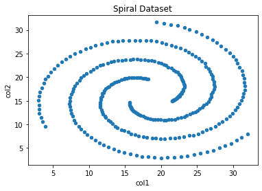

```python
import pandas as pd
import matplotlib.pyplot as plt
%matplotlib inline

result4.plot.scatter(x='col1', y='col2')
plt.title('Spiral Dataset')
```

1. Calculate the SSE and plot sum-of-squared errors (SSE) versus k

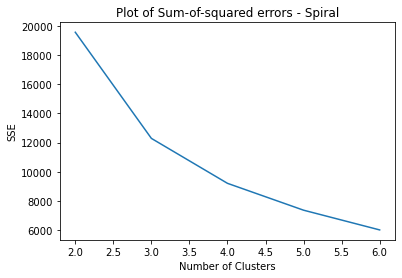

```python
import matplotlib.pyplot as plt
%matplotlib inline

numClusters = [2,3,4,5,6]
SSE = []
for k in numClusters:
    k_means = cluster.KMeans(n_clusters=k)
    k_means.fit(spiral)
    SSE.append(k_means.inertia_)

plt.plot(numClusters, SSE)
plt.title('Plot of Sum-of-squared errors - Spiral')
plt.xlabel('Number of Clusters')
plt.ylabel('SSE')
```

1. Discuss the results of part (2) and (3)

For part (2) I noticed the visually obvious contiguous clusters For part (3) I noticed the value of the best K was at not obvious

### Part II:

1. Perform DBSCAN clustering on different data sets using different Eps and MinPt
2. Draw the distance to k nearest point versus k (for different k)
   - Try to find the estimation of Eps and MinPt (see DBSCAN: Determining EPS and MinPts slide)

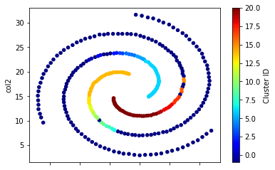

```python
from sklearn.cluster import DBSCAN
import numpy as np

db = DBSCAN(eps=0.5, min_samples=2).fit(data4)
labels = pd.DataFrame(db.labels_,columns=['Cluster ID'])
result = pd.concat((data4,labels), axis=1)
result.plot.scatter(x='col1', y='col2',c='Cluster ID', colormap='jet')
```

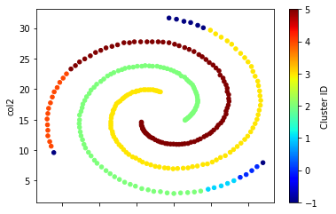

```python
from sklearn.cluster import DBSCAN
import numpy as np

db = DBSCAN(eps=1, min_samples=3).fit(data4)
labels = pd.DataFrame(db.labels_,columns=['Cluster ID'])
result = pd.concat((data4,labels), axis=1)
result.plot.scatter(x='col1', y='col2',c='Cluster ID', colormap='jet')
```

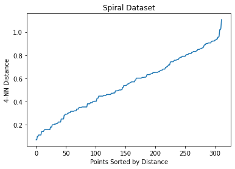

```python
from sklearn.neighbors import NearestNeighbors
import numpy as np
from scipy.spatial import distance

neighbors = NearestNeighbors(n_neighbors = 4)
neighbors_fit = neighbors.fit(spiral)
distances, indices = neighbors_fit.kneighbors(spiral)

distances = np.sort(distances, axis=0)
distances = distances[:,1]
plt.plot(distances)
plt.ylabel('4-NN Distance')
plt.xlabel('Points Sorted by Distance')
plt.title('Spiral Dataset')
```

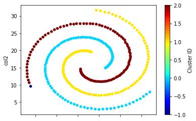

```python
from sklearn.cluster import DBSCAN
import numpy as np

db = DBSCAN(eps=1.1, min_samples=3).fit(data4)
labels = pd.DataFrame(db.labels_,columns=['Cluster ID'])
result = pd.concat((data4,labels), axis=1)
result.plot.scatter(x='col1', y='col2',c='Cluster ID', colormap='jet')
```

### Part III:

1. Compare the results of part I and II and discuss the advantages and limitations

Part I didn't have color distinguished pictorial depiction of the points where as Part II did have multiple vartiations of that distinguished pictorial depiction. Ultimately yeilding better clusters.

In this section, the non-globals was a limitation